# MaL - Zaklady programovani v R

Jan Schubert, Ivan Petrusek

V tomto cviceni se budeme venovat nekolika zakladnim konceptum, ktere vam umozni vyuzit naplno vyhody programovaciho jazyke. Toto cviceni mozna nebude tak zabavne jako ty predchozi :), ale o to vice bude uzitecne.

Prvni koncept, ktery si vysvetlime je princip working directory. Kazdy soubor na vasem pocitaci (nebo na jakemkoliv serveru) je ulozen v adresari pod urcitou cestou (path). Tato cesta (path) rika vasemu operacnimu systemu, kde se soubor nachazi. Stejne tak ji budeme pouzivat my, abychom dali R vedet, ze chceme napriklad nacist soubor z urciteho mista. Cesty (paths) mohou byt bud:

1. Absolutni
2. Relativni

Kazdy operacni system ma domovsky adresar, od ktereho zacinaji vsechny ostatni cesty. V programu Windows je to vetsinou `C:/Users/`, v systemu Linux vetsinou `/root/`. Absolutni cesta uplnou cestu k vasemu souboru od domovskeho adresare. Vytisknout si ji muzete pomoci funkce `getwd()`.

```r
getwd()
```

```
## [1] "C:/Users/schubertj/OneDrive - Kantar/Documents/MaL/Cviceni 4"
```

Vetsinou ale nebudete pracovat v domovskem adresari a vypisovani cele cesty muze byt zdlouhave. Proto budete vetsinou pouzivat relativni cestu k vasemu souboru. Jak vidite z me working directory, pracuji prave v adresari Cviceni 4. Pokud bych chtel napriklad do R nacist soubor z tohoto adresare, muzu bud vypsat celou cestu, nebo vyuzit relativni cesty, ktera se v R znaci pomoci tecky - `.`. Kuprikladu mohu vytisknout vsechny soubory v mem soucasnem adresari pomoci prikazu `list.files("./")` aniz bych musel specifikovat celou cestu k memu adresari `C:/Users/schubertj/OneDrive - Kantar/Documents/MaL/Cviceni 4`.

```r
list.files("./")
```

```
##  [1] "data_strednik.csv"
##  [2] "data_strednik_carka_desetinne.csv"
##  [3] "data_strednik_no_header.csv"
##  [4] "MaL - Zaklady programovani v R.Rmd"
##  [5] "MaL_-_Zaklady_programovani_v_R.html"
##  [6] "MaL_-_Zaklady_programovani_v_R.Rmd"
##  [7] "spotify.csv"
##  [8] "spss_import.png"
##  [9] "utils_cviceni4.r"
## [10] "V2006_F1.sav"
```

Vasi working directory si muzete nastavit pomoci funkce `setwd`, ktera ma jediny argument a tim je cesta k adresari, ktery chcete nastavit jako misto, kde bude R hledat v souborech.

```r
setwd("C:/Users/schubertj/OneDrive - Kantar/Documents/MaL")
```

Ted se zamerime na to, jak muzeme do R nacist externi data. Doted jsme vsechna data, ktera jsme pouzivali zadavali do R primo. V realnem pouzivani ale budete temer vzdy pouzivat externi data. Nejcasteji budete nacitat data ve formatu csv. V base R muzete k nacteni pouzit funkci `read.csv`. Vetsina parametru funkce `read.csv` ma nejaky default a tak jedinym povinnym argumentem je `file`, kde specikujete cestu k souboru, ktery chcete nacist. To bude vetsinou cesta ve vasem pocitaci (viz predchozi koncept o absolutni a relativni ceste), ale muzete to byt i odkaz na csv soubor ulozeny na internetu. Pojdme si zkusit nacist data ze spotify, ktera obsahuji data o ruznych zanrech. [Zde](https://github.com/rfordatascience/tidytuesday/blob/master/data/2020/2020-01-21/readme.md) se muzete dozvedet vice o techto datech.

```r
spotify <- read.csv("https://raw.githubusercontent.com/rfordatascience/tidytuesday/master/data/2020/2020-01-21/spotify_songs.csv")

head(spotify)
```

```
##                 track_id
## 1 6f807x0ima9a1j3VPbc7VN
## 2 0r7CVbZTWZgbTCYdfa2P31
## 3 1z1Hg7Vb0AhHDiEmnDE79l
## 4 75FpbthrwQmzHlBJLuGdC7
## 5 1e8PAfcKUYoKkxPhrHqw4x
## 6 7fvUMiyapMsRRxr07cU8Ef
##                                              track_name     track_artist
## 1 I Don't Care (with Justin Bieber) - Loud Luxury Remix       Ed Sheeran
## 2                       Memories - Dillon Francis Remix         Maroon 5
## 3                       All the Time - Don Diablo Remix     Zara Larsson
## 4                     Call You Mine - Keanu Silva Remix The Chainsmokers
## 5               Someone You Loved - Future Humans Remix    Lewis Capaldi
## 6     Beautiful People (feat. Khalid) - Jack Wins Remix       Ed Sheeran
##   track_popularity         track_album_id
```

[output cut: 41 more lines]

V tomto pripade se data nacetla v poradku se zakladnimi hodnotami ostatnich parametru. Ne vzdy to ale bude tak snadne. Pojdte si nyni projit nektere z dalsich parametru, ktere budeme potrebovat cas od casu zmenit. Prvnim argumentem, na ktery se podivame je `sep`. Tento argument rika R, jaky symbol ma pouzit na rozdeleni radku. Vetsina csv souboru pouziva `,`, ale v Cesku je bezne pouzivat jako oddelovaci symbol `;`. Zakladni nasteveni (`sep = ","`) muzete zmenit na jakykoliv symbol:

- `sep = ";"` pro strednik
- `sep = "\t"` pro tabulator
- `sep = " "` pro mezeru

Zde je priklad nacteni souboru, ktery je oddeleny strednikem

```r
read.csv("https://raw.githubusercontent.com/schubertjan/cviceni_4/master/data_strednik.csv",
         sep = ";")
```

```
##    cviceni      datum
## 1        1 2020-10-06
## 2        2 2020-10-13
## 3        3 2020-10-20
## 4        4 2020-10-27
## 5        5 2020-11-03
## 6        6 2020-11-10
## 7        7 2020-11-17
## 8        8 2020-11-24
## 9        9 2020-12-01
## 10      10 2020-12-08
```

Stejne tak dulezity je argument `dec`. V nem specifikujete, jaky symbol ma R ocekavat v cislech na miste desetinne carky. Vetsinou (ne vsak vzdy, je potreba zkontrolovat) plati nasledujici:

- pokud je csv dokument oddelen carkou, bude symbol na desetinna mista tecka `.`
- pokud je csv dokument oddelen strednikem, bude symbol na desetinna mista carka `,`

Jak si muzete precist v napovede `?read.csv`, defaultni hodnotou je `dec = "."`. Zde je priklad nacteni souboru se symbolem `,` na miste desetinne carky. Jak vidite, sloupec 1 je nacten spravne jako cislo.

```r
df <- read.csv("https://raw.githubusercontent.com/schubertjan/cviceni_4/master/data_strednik_carka_desetinne.csv",
         sep = ";",
         dec = ",")
print(df)
```

```
##    cviceni      datum
## 1      1.2 2020-10-06
## 2      2.2 2020-10-13
## 3      3.1 2020-10-20
## 4      4.1 2020-10-27
## 5      5.1 2020-11-03
## 6      6.1 2020-11-10
## 7      7.1 2020-11-17
## 8      8.1 2020-11-24
## 9      9.1 2020-12-01
## 10    10.1 2020-12-08
```

```r
class(df[, 1])
```

```
## [1] "numeric"
```

Dalsim dulezitym argumentem, ktery uvedeme je `header`. Ten udava, zda ma R pouzit prvni radek dat jako nazev sloupcu vasi tabulky. Defaultni nastaveni je `header = TRUE`. Pokud vase data neobsahuji nazvy sloupcu pouzijte `header=FALSE`. Jak vidite vsechna data se nacetla v poradku. Protoze kazdy `data.frame` potrebuje nejake nazvy sloupcu, pouzije `R` defaultni nazvy `V1` atd.

```r
df <- read.csv("https://raw.githubusercontent.com/schubertjan/cviceni_4/master/data_strednik_no_header.csv", sep = ";", dec = ",", header = FALSE)

print(df)
```

```
##      V1         V2
## 1   1.2 2020-10-06
## 2   2.2 2020-10-13
## 3   3.1 2020-10-20
## 4   4.1 2020-10-27
## 5   5.1 2020-11-03
## 6   6.1 2020-11-10
## 7   7.1 2020-11-17
## 8   8.1 2020-11-24
## 9   9.1 2020-12-01
## 10 10.1 2020-12-08
```

```r
class(df[, 1])
```

```
## [1] "numeric"
```

K ukazce posledniho argementu si nejdrive musime priblizit koncept faktoru (factors). Faktory jsou dalsi tridou (class), kterou muze vektor nabyt (uz zname numeric a character). Faktory se pouzivaji k reprezantaci kategorialnich dat (jako napriklad dotaznikove skaly). Vypadaji jako textove vektory, ale rozdil je, ze kazda hodnota ma za sebou cislo, diky kteremu jsou hodnoty serazeny. Textove vektory jsou serazeny pouze podle abecedy.

```r
text <- c("velmi spatny", "spatny", "dobry", "velmi dobry")
skala <- factor(x = text,
                levels = c("velmi dobry", "dobry", "spatny", "velmi spatny"))
sort(text)
```

```
## [1] "dobry"        "spatny"       "velmi dobry"  "velmi spatny"
```

```r
sort(skala)
```

```
## [1] velmi dobry  dobry        spatny       velmi spatny
## Levels: velmi dobry dobry spatny velmi spatny
```

Vsechny textove promenne jsou automaticky nacteny jako factory ve funkci `read.csv`. Pokud chcete toto nastaveni zmenit a nacist textove promenne jako textove pouzijte `stringsAsFactors = FALSE`. Nacteme data jeste jednou, tentokrat chceme nacist textove promenne jako textove, ne jako faktory.

```r
spotify <- read.csv("https://raw.githubusercontent.com/rfordatascience/tidytuesday/master/data/2020/2020-01-21/spotify_songs.csv",
                    stringsAsFactors = FALSE)
```

Stejne tak muzete vami vytvorene datove matice ulozit do csv souboru pomoci funkce `write.csv`. Vetsina klicovych argumentu jako `path` nebo `sep` jsou shodne s predchozi funkci. Dalsimi dulezitymi argumenty jsou `row.names` a `col.names`, ktere nabiraji hodnot `TRUE`/`FALSE` a znaci, zda chcete ulozit nazvy radku nebo sloupcu. Objekt, ktery chcete z vasi R session ulozit specifikujete v argumentu `x`.

```r
#ulozme prvnich 5 radku z dat spotify
spotify_5row <- head(spotify, 5)
write.csv(file = "spotify.csv", x = spotify_5row, row.names = FALSE)
```

Posledni zpusob importovani dat, ktery si ukazeme, je import souboru vytvorenych v programu SPSS (koncici priponou .sav). SPSS je program pouzivanych pri analyze sociologickych dat. Importovat ho muzete pomoci nabidky v programu Rstudio.

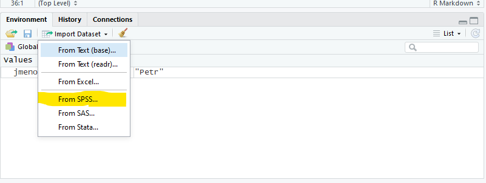

Nebo pomoci nasledujiciho kodu.

```r
library(haven)
spss_data <- read_sav("./V2006_F1.sav")
```

```r
#nejdrive si ukazeme jednoduchy prikla, abychom vysvetlili principy for loops
cisla <- c(1:5)
for(cislo in cisla) {
  print(cislo)
}
```

```
## [1] 1
## [1] 2
## [1] 3
## [1] 4
## [1] 5
```

```r
zari1 <- 368
delka_predikce <- 30
rate <- 1.06

#vytvorime prazdny vektor, do ktereho budeme ukladat denni prirustky
denni_narust <- rep(NA, delka_predikce)
# do prvni hodnoty dosadime 1.zari
denni_narust[1] <- zari1

#for loop
for(i in 2:delka_predikce) {
  denni_narust[i] = denni_narust[i-1] * rate
}

#hodnota na konci zari
tail(denni_narust, 1)
```

```
## [1] 1993.967
```

Vratme se nyni k nasim datum o pisnich ze spotify. Nejdrive se podivame na dimenze nasich dat.

```r
dim(spotify)
```

```
## [1] 32833    23
```

Dalsi uzitecna funkci `str`, ktera nam pomuze rychle zjistit, jake tridy (class) jsou jednotlive promenne.

```r
str(spotify)
```

```
## 'data.frame':    32833 obs. of  23 variables:
##  $ track_id                : chr  "6f807x0ima9a1j3VPbc7VN" "0r7CVbZTWZgbTCYdfa2P31" "1z1Hg7Vb0AhHDiEmnDE79l" "75FpbthrwQmzHlBJLuGdC7" ...
##  $ track_name              : chr  "I Don't Care (with Justin Bieber) - Loud Luxury Remix" "Memories - Dillon Francis Remix" "All the Time - Don Diablo Remix" "Call You Mine - Keanu Silva Remix" ...
##  $ track_artist            : chr  "Ed Sheeran" "Maroon 5" "Zara Larsson" "The Chainsmokers" ...
##  $ track_popularity        : int  66 67 70 60 69 67 62 69 68 67 ...
##  $ track_album_id          : chr  "2oCs0DGTsRO98Gh5ZSl2Cx" "63rPSO264uRjW1X5E6cWv6" "1HoSmj2eLcsrR0vE9gThr4" "1nqYsOef1yKKuGOVchbsk6" ...
##  $ track_album_name        : chr  "I Don't Care (with Justin Bieber) [Loud Luxury Remix]" "Memories (Dillon Francis Remix)" "All the Time (Don Diablo Remix)" "Call You Mine - The Remixes" ...
##  $ track_album_release_date: chr  "2019-06-14" "2019-12-13" "2019-07-05" "2019-07-19" ...
##  $ playlist_name           : chr  "Pop Remix" "Pop Remix" "Pop Remix" "Pop Remix" ...
##  $ playlist_id             : chr  "37i9dQZF1DXcZDD7cfEKhW" "37i9dQZF1DXcZDD7cfEKhW" "37i9dQZF1DXcZDD7cfEKhW" "37i9dQZF1DXcZDD7cfEKhW" ...
##  $ playlist_genre          : chr  "pop" "pop" "pop" "pop" ...
##  $ playlist_subgenre       : chr  "dance pop" "dance pop" "dance pop" "dance pop" ...
##  $ danceability            : num  0.748 0.726 0.675 0.718 0.65 0.675 0.449 0.542 0.594 0.642 ...
##  $ energy                  : num  0.916 0.815 0.931 0.93 0.833 0.919 0.856 0.903 0.935 0.818 ...
##  $ key                     : int  6 11 1 7 1 8 5 4 8 2 ...
##  $ loudness                : num  -2.63 -4.97 -3.43 -3.78 -4.67 ...
##  $ mode                    : int  1 1 0 1 1 1 0 0 1 1 ...
##  $ speechiness             : num  0.0583 0.0373 0.0742 0.102 0.0359 0.127 0.0623 0.0434 0.0565 0.032 ...
##  $ acousticness            : num  0.102 0.0724 0.0794 0.0287 0.0803 0.0799 0.187 0.0335 0.0249 0.0567 ...
##  $ instrumentalness        : num  0.00 4.21e-03 2.33e-05 9.43e-06 0.00 0.00 0.00 4.83e-06 3.97e-06 0.00 ...
##  $ liveness                : num  0.0653 0.357 0.11 0.204 0.0833 0.143 0.176 0.111 0.637 0.0919 ...
##  $ valence                 : num  0.518 0.693 0.613 0.277 0.725 0.585 0.152 0.367 0.366 0.59 ...
##  $ tempo                   : num  122 100 124 122 124 ...
##  $ duration_ms             : int  194754 162600 176616 169093 189052 163049 187675 207619 193187 253040 ...
```

Rekneme, ze bychom chteli udelat urcitou operaci pouze pokud dana hodnota splnuje urcitou podminku. `valance` vyjadruje pozitivitu pisnisky. Muze nabyt hodnot od 0 do 1, kde 0 znaci smutnou a 1 veselou melodii. Chceme vytvorit novou promennou `valance_type`, ktera bude nabyvat dvou hodnot: “pozitivni” pokud valance je > 0.5 a “negativni” pokud valance je <= 0.5. K temto operacim pouzivame `if` statementy. Nasledujici kod ukazuje, jak pouzit `if` na operaci, kterou chceme provest.

Nejdrive si celou operaci ukazeme na jednoduchem pripadu, abychom pochopili principy `if` statementu.

```r
jmeno <- c("Petr")

if(jmeno == "Petr") {
  print("toto je Petr")
} else {
  print("totovje nekdo jiny")
}
```

```
## [1] "toto je Petr"
```

```r
jmeno <- "Pavel"
if(jmeno == "Petr") {
  print("toto je Petr")
} else if(jmeno == "Pavel") {
  print("toto je Pavel")
} else {
  print("toto je nekdo jiny")
}
```

```
## [1] "toto je Pavel"
```

Jak jste si vsimli podminka v `if` muze mit pouze jednu hodnotu. Pro nas pripad tedy budeme muset zkombinovat `for` a `if`.

```r
#nejdrive vytvorime novou promennou, do ktere budeme ukladat vysledky a naplnime ji dummy hodnout (napriklad 0)
spotify$valence_type <- 0

pocet_radku <- dim(spotify)[1]

for(i in 1:pocet_radku) {
  if(spotify$valence[i] > 0.5) {
    spotify$valence_type[i] <- "pozitivni"
  } else if(spotify$valence[i] <= 0.5) {
    spotify$valence_type[i] <- "negativni"
  }
}

table(spotify$valence_type)
```

```
##
## negativni pozitivni
##     15830     17003
```

```r
spotify$valance_type2 <- ifelse(spotify$valence > 0.5, "pozitivni", "negativni")

all(spotify$valance_type1 == spotify$valance_type2)
```

```
## [1] TRUE
```